# HW9

# Problem 2: Grocery store prices

## Part A.

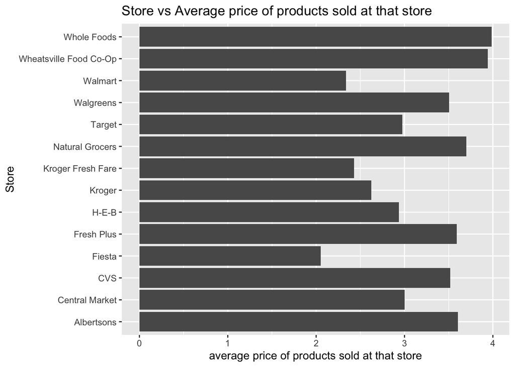

The bar plot shows the average product price by store. Whole Foods and Wheatsville Food Co-Op generally have high average prices, while stores like Walmart and Fiesta have low average prices. In generally these stores are known to offer more cheaper alternatives, while the more expensive stores offer more premium products.

## Part B.

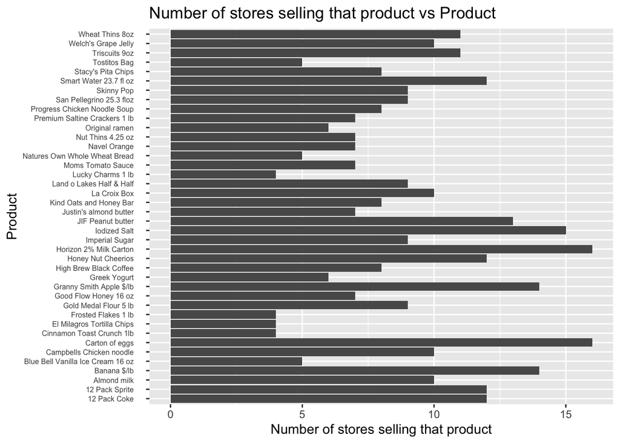

The bar plot shows the number of stores carrying each product. Lucky Charms and Frosted Flakes generally have lower counts, while products like 2% milk and eggs have high counts. In general, products like cereal that are less fresh, are not as popular as fresh products like eggs or milk.